# Project: Investigate a European Soccer Database

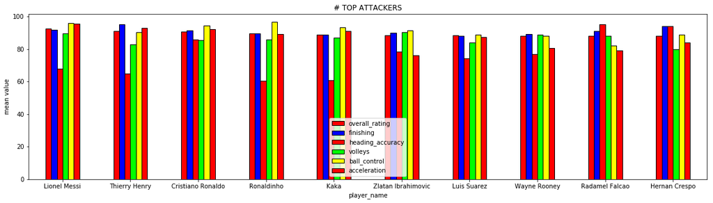

```python
df_attacker_top[['overall_rating', 'finishing', 'heading_accuracy',
       'volleys','ball_control','acceleration']][:10].plot(kind = "bar",figsize=(20,5),
                                                  color =["r","b","red","lime","yellow"],
                                                  linewidth = 1,
                                                  edgecolor = "k"*10
                                                 )
plt.xticks(rotation =0)
plt.legend(loc ="lower center")
plt.ylabel("mean value")
plt.title("# TOP ATTACKERS")
plt.show()
```

> Fig 10: Top Attackers. In topten of strikers, I will pick up Thierry Herry because of this finishing. But anyhow, We have to bring out with a shopping list because most guys in this list are not fore sale

```python
df_attacker_top.head(10)
```

| player_name | player_api_id | player_name | overall_rating | finishing | heading_accuracy | volleys | ball_control | acceleration |
| --- | --- | --- | --- | --- | --- | --- | --- | --- |
| Lionel Messi | 30981 | Lionel Messi | 92.666667 | 92.000000 | 68.000000 | 89.666667 | 96.000000 | 95.666667 |
| Thierry Henry | 30626 | Thierry Henry | 91.000000 | 95.000000 | 65.000000 | 83.000000 | 90.500000 | 93.000000 |
| Cristiano Ronaldo | 30893 | Cristiano Ronaldo | 90.833333 | 91.416667 | 86.000000 | 85.333333 | 94.500000 | 92.083333 |
| Ronaldinho | 30743 | Ronaldinho | 89.666667 | 89.666667 | 60.333333 | 86.000000 | 96.666667 | 89.333333 |
| Kaka | 41044 | Kaka | 88.666667 | 89.000000 | 61.000000 | 87.000000 | 93.166667 | 91.000000 |
| Zlatan Ibrahimovic | 35724 | Zlatan Ibrahimovic | 88.533333 | 90.133333 | 78.466667 | 90.200000 | 91.333333 | 76.066667 |
| Luis Suarez | 40636 | Luis Suarez | 88.285714 | 88.142857 | 74.428571 | 83.857143 | 88.714286 | 87.285714 |
| Wayne Rooney | 30829 | Wayne Rooney | 88.058824 | 89.352941 | 77.000000 | 88.941176 | 88.176471 | 80.705882 |
| Radamel Falcao | 22543 | Radamel Falcao | 88.000000 | 91.000000 | 95.000000 | 88.000000 | 82.000000 | 79.000000 |
| Hernan Crespo | 35561 | Hernan Crespo | 88.000000 | 94.000000 | 94.000000 | 80.000000 | 89.000000 | 84.000000 |

```python
#Find down top play makers
df_play_maker_index = df_merged_player[["player_api_id",'balance', 'crossing', 'ball_control','acceleration', 'player_name','preferred_foot',"overall_rating"]]
df_play_maker_index.drop_duplicates(inplace=True)
df_play_maker_index = df_play_maker_index[(df_play_maker_index["overall_rating"]>85)
                      & (df_play_maker_index["balance"]>85)& (df_play_maker_index["ball_control"]>90)
                        & (df_play_maker_index["crossing"]>75) ]
df_play_maker_index = df_play_maker_index.groupby(["player_api_id","player_name"])[['overall_rating', 'balance', 'crossing','ball_control','acceleration']].mean()
df_play_maker_index = df_play_maker_index.sort_values(by="overall_rating",ascending =False).reset_index()
df_play_maker_index.index = df_play_maker_index["player_name"]
```

[output not shown]

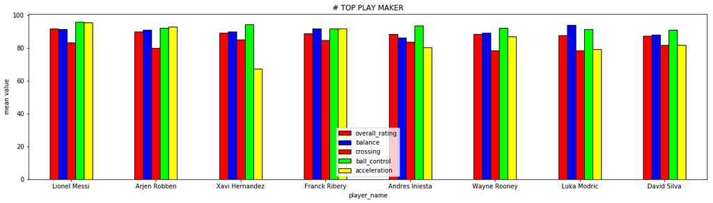

```python
df_play_maker_index[['overall_rating', 'balance', 'crossing',
       'ball_control','acceleration']][:10].plot(kind = "bar",figsize=(20,5),
                                                  color =["r","b","red","lime","yellow"],
                                                  linewidth = 1,
                                                  edgecolor = "k"*10
                                                 )
plt.xticks(rotation =0)
plt.legend(loc ="lower center")
plt.ylabel("mean value")
plt.title("# TOP PLAY MAKER")
plt.show()
```

> Fig 11: Top Play makers. I take the ball control over other parameters. In this chart, we can see that Xavi should be in my dream team

```python
df_play_maker_index.head()
```

| player_name | player_api_id | player_name | overall_rating | balance | crossing | ball_control | acceleration |
| --- | --- | --- | --- | --- | --- | --- | --- |
| Lionel Messi | 30981 | Lionel Messi | 91.900000 | 91.400000 | 83.300000 | 95.800000 | 95.300000 |
| Arjen Robben | 30834 | Arjen Robben | 90.000000 | 91.000000 | 80.000000 | 92.000000 | 93.000000 |
| Xavi Hernandez | 39854 | Xavi Hernandez | 89.333333 | 90.000000 | 85.000000 | 94.166667 | 67.333333 |
| Franck Ribery | 30924 | Franck Ribery | 88.714286 | 91.857143 | 84.571429 | 91.714286 | 91.571429 |
| Andres Iniesta | 30955 | Andres Iniesta | 88.400000 | 86.100000 | 83.600000 | 93.500000 | 80.300000 |

## Conclusions

> Question 1: Which club should I buy My target is this club should be in a one of leauges have most game to play to attract media. this club has also in the top of home/away goals Based on Fig 5,6 and 7. I pick up PSV. This club is in the top of home/away goal. They are also in league have a lot game to play. The violin chart have also said that the resutl in Netherlands Eredivisie is quite unpredicable, indicates by hight outlier.

> Question 2: Which players I have to buy? The quality of players is based on the metric values in the field they play. What we have to do is analysis & pick up the top players in each field, goal keeper, defencer, play makers and striker.

> Goal keeper: I sort out goalies based on their metric: gk_diving, gk_handling, gk_kicking, gk_positioning, gk_reflexes. And, I pick up only top 5 of them who have high score. So, it returns to me with the list: Gianluigi Buffon, Gregory Coupet in fig 8

> Defences: based on the metrics: strength, standing_tackle, sliding_tackle and overall_rating. I got fig 9 & the list of top defencers: Alessandro Nesta, Cris, Jamie Carragher, Marco Materazzi, John Terry, Bastian Schweinsteiger

> Playmakers: Based on the metrics: overall_rating, balance, crossing, ball_control and acceleration, I analysized the top of players & showed by Fig 11. The list of players is: Arjen Robben, Xavi Hernandez, Franck Ribery, Andres Iniesta

> Strikers: Metrics: overall_rating, overall_rating, heading_accuracy, volleys, ball_control and acceleration, the list has been showed in Fig 10: Lionel Messi, Thierry Henry, Luis Suarez, Wayne Rooney, Cristiano Ronaldo

## Limitations

> I wish I could have a year to dive deeper into this assignment. But, for the very first data analysis, I have tried to do my best. Bellow are some point I could have deveploped in the future:
> 1. Based on players record. I should point out the relationship between height, weigh and their's overal value.
> 2. The overal value could be the most important value to index the quality of player. But, I don't have any clue to find down how to calculate this value.
> 3. I always want to have some players with left footed in my team. I hope to pick up a swinger and left defender by the outcome table. But I am not able to get to done.